# Why Should We End Mass Incarceration?

Linda Li

2022-11-01

## Abstract

The U.S. has the highest incarceration rate in the world. The U.S. has arrested low-level behavior in racist ways throughout history, particularly against Black people. It’s important to reduce the use of prisons and unjustified incarceration. **This report exposes patterns of inequality of our prison system by analyzing the incarceration data.** It also tends to call for action to fight against unjustified incarceration.

## Introduction

The U.S. is the **most incarcerated nation** in the world. Mass incarceration also has been a historic phenomenon throughout our history. Politicians started to link crime with race. Jails and prisons today are filled with people who have been targeted by **overcriminalization and racial profiling**. Our country has been overarrest people of color and poverty. Many people stay in jail because they can’t afford bail. Based on *Data Feminism*, those researchers analyze and expose oppression to hold institutions accountable. The goal is to challenge the power. Therefore, it’s important for us to make changes to our criminal legal system and stop unnecessary use of jails.

The direct stakeholder of this dataset are the government officials and those who are in jail due to overcriminalization. The government can better understand and improve the existing problems in criminal legal system. Those who are in jail can eventually get their rights back. The indirect stakeholder would be citizens in the U.S. By eliminating mass incarceration, we can build safer communities and gain equality for everyone. The central value is human dignity and justice since ending the unjust system can affirm human dignity and bring more justice to those minoritized groups.

## Data Summary

In 1990, the average value of total county population aged 15 to 64 of Black people in prison is **6053**. This value is important because we can compare the average value of Black people to other color to see how the inequality in the prison system relates to race.

The highest value of total county population aged 15 to 64 of Black people in 1990 is **1252071**. The lowest value of total county population aged 15 to 64 of Black people in 1990 is **0**. These values are essential because they can show when and where the the most value was. This relates to the area where the most patterns of inequality happened.

The value of total county population aged 15 to 64 of Black people has increased **8594** from 1980 to 1990. This value is important because it shows how the trend of inequality increased over the 10 years.

## Growth of the U.S. Prison Population

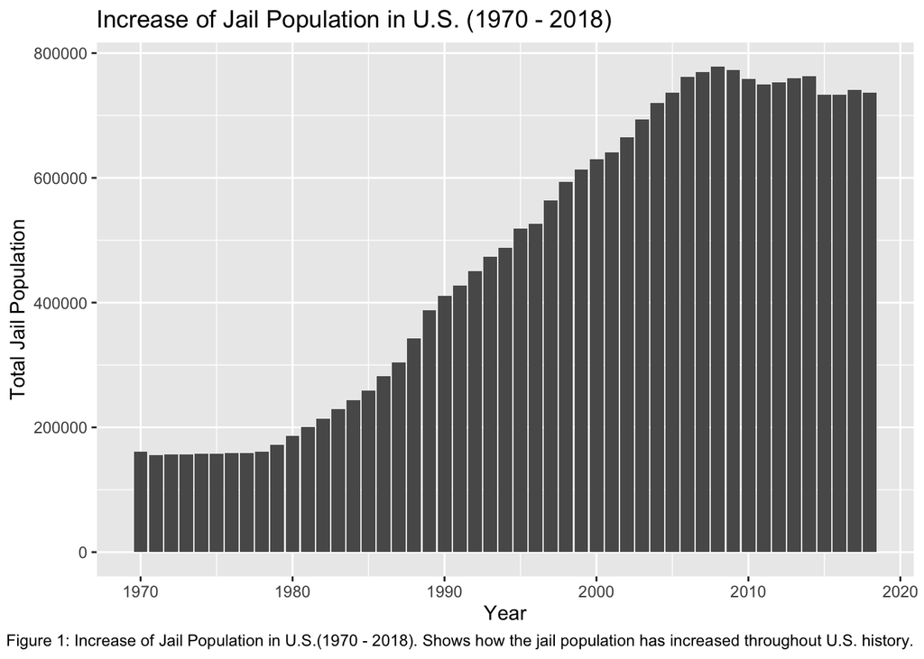

According to the bar chart, the overall pattern of U.S. prison population has **increased** greatly from 1970 to 2018. The jail population did not change much until 1980. Also, the jail population has been slowly decreasing since 2008, indicating that there can be improvement on our prison system to reduce unnecessary use of prisons. My question regarding this graph is: What are some key events that caused the great increase of jail population in U.S. since 1980?

## Growth of Prison Population by State

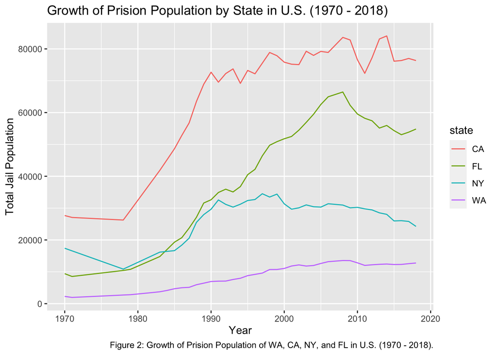

## Growth of Prison Population by Race and Urbanicity

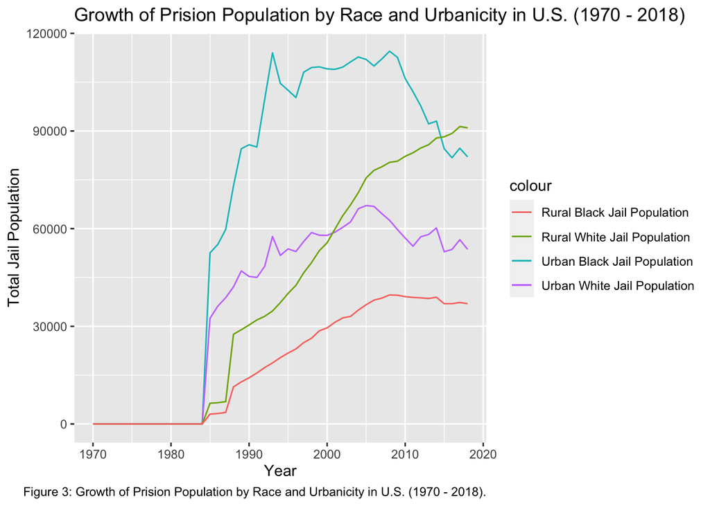

## County Total Black Population in Jail in California

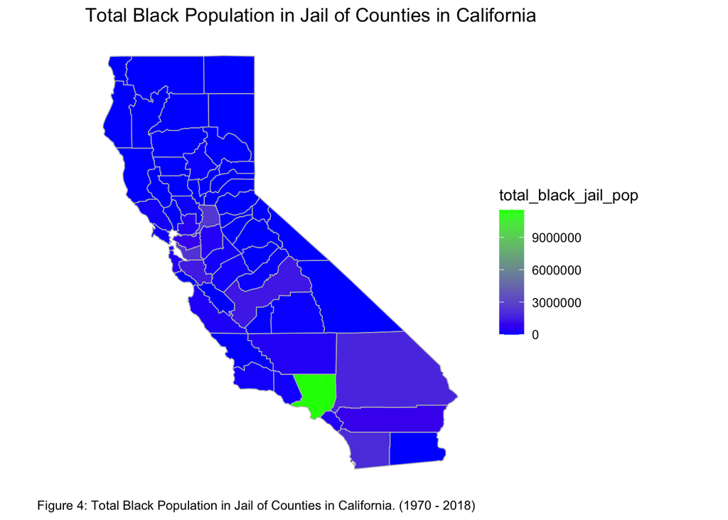

The graph shows the total Black population in jail by counties in California from 1970 to 2018. According to the plot, the total Black Population in prison is the greatest in Los Angeles. Southern California tends to have a much greater black population in prison comparing to other area in California. The counties in the bay area also have more total black population in jail comparing to northern California. My question regarding the graph is: What are some factors that can cause the big population in these specific areas in California?